# Mapping the Social Epidemiology of Preterm Birth: Model Architecture

# Model architecture overview

This README document outlines the March of Dimes (MoD) ‘Mapping the Social Epidemiology of Preterm Birth’ model architecture. It is meant to be a reference and a guide for anyone who would like to run the model on their own.

This model requires two primary file folder structures: data and code. Setting each up is outlined below

# Running the model

## Setting up environment

### Data

Your local data folder structure should reflect that which is currently on the Box ‘March of Dimes_ShareFolder’, seen below:

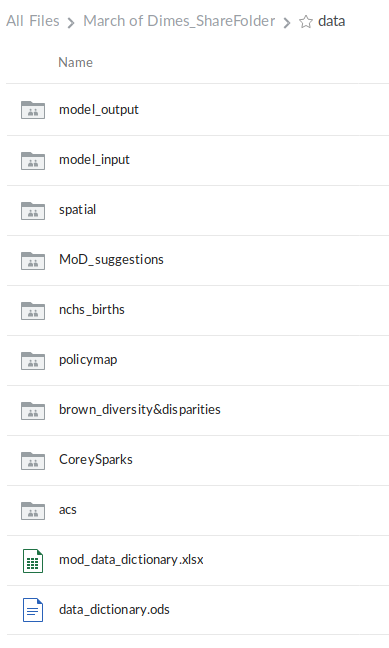

Data folder structure

### Code

Your local code repo should be a forked copy of Michael Kramer’s [mod_geodisparities](https://github.com/mkram01/mod-geodisparities) repo.

Once forked and cloned locally, your repo should look like this:

[figure not shown]

Code repo structure

If you are new to Git or the Fork-and-Branch workflow, I recommend the following resources:

- [A good introduction](https://blog.scottlowe.org/2015/01/14/non-programmer-git-intro/)
- [Using Git with GitHub](https://blog.scottlowe.org/2015/01/26/using-git-with-github/)
- [Fork-and-Branch flow](https://blog.scottlowe.org/2015/01/27/using-fork-branch-git-workflow/)
- [Git cheatsheet](https://education.github.com/git-cheat-sheet-education.pdf)
- [Happy Git and GitHub for the useR](https://happygitwithr.com/index.html)

### Global environment variables

Environment variables help make code more dynamic and eliminates dependencies on hard-coding things like file paths. Feel free to set these however you please, [here](https://astrostatistics.psu.edu/su07/R/html/base/html/Sys.setenv.html) is a solution for setting them from the R console.

This model relies on 3 global environment variables that need to be set in your working environment:

1. `mod_repo`: the path to the MoD code repo in your working environment
   - **Example:** */home/e/Documents/git_repos/mod-geodisparities/*
   - Called at start of model: `repo <- Sys.getenv('mod_repo')`
2. `mod_data`: the path to the MoD data in your working environment
   - **Example:** */home/e/MoD/data*
   - Called at start of model: `data_repo <- Sys.getenv('mod_data')`
3. `mod_modeler`: the character value representing you, the modeler. This is used when writing the model run report.
   - **Example:** *“Erin”*
   - Called at start of model: `modeler <- Sys.getenv('mod_modeler)`

### Packages

Any packages not currently in your library will automatically be installed and called.

## Config

The config file contains the parameters controlling the dynamic components of the model.

The config file lives in your data repo here:

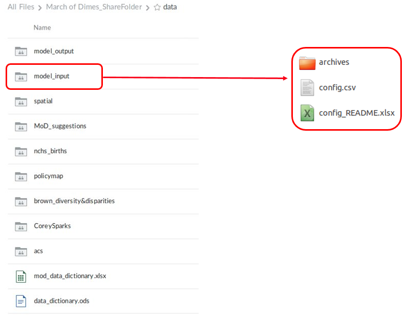

Config file location inside the data folder hierarchy

An example of how your config file might look:

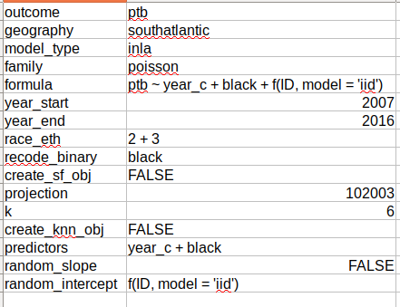

Config example

To fill in your arguments, please refer to the `config_README.xlsx` document in the same folder as the csv.

## Launch

After you have altered arguments in the config file, the launch file should be the only other component you need to interact with and is all you need to open to run the model. Simply open `launch.R` and run all.

## Outputs

The name and location of your model outputs are dynamically created from your config arguments and from a time stamp.

The output hierarchy is as follows and is pictured below: model_type -> family -> outcome -> geography

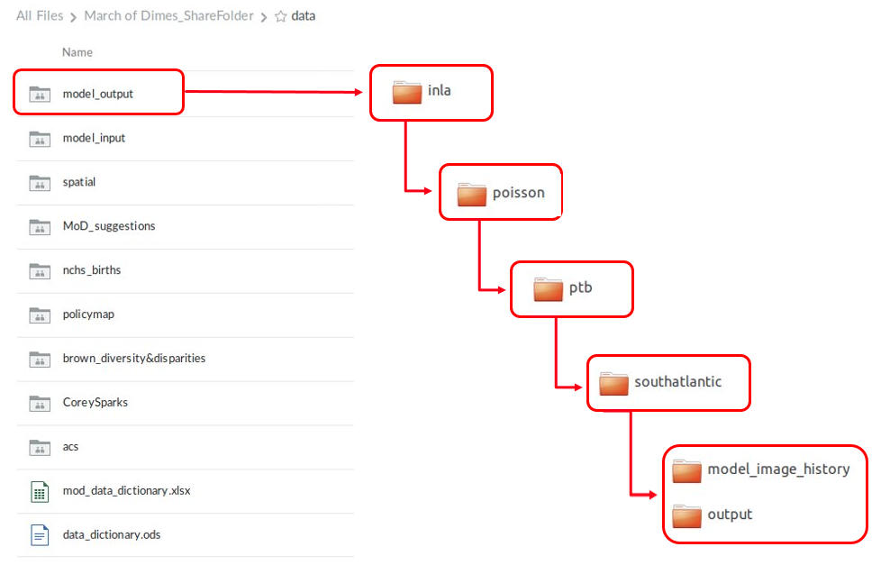

Model output hierarchy

The model name is a concatenation of the following config arguments:

- year_start
- year_end
- random_slope
- random_intercept
- run date

Automatic outputs currently include:

- Model fitted value estimates in a table with raw data inputs (’…_fittedvals.csv’)
- Timed summary of how long each component took to run (’…_run_summary.csv’)

Conditional outputs currently include:

- If the config arg `save_mod` is toggled on: Model object (.rds)
- If the config arg `visualize` is toggled on: Model report (.html)

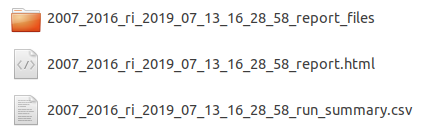

Final model outputs

# About the data & scripts

### Important details about the data being used & created:

- Currently, the base county geospatial data is from 2016. This layer is being used to create the spatial weights and for visualization.
  - To change this as the baselayer for creating spatial weights, you can define the `baselayer` arg in the `create_adjmatrix` function (located: `data_prep/data_prep_fxns.R`) called in the `precreate_adjmatrices.R` script
  - To change this as the baselayer for visualization, you can define the `baselayer` arge in the `load_spatialdata` function (located: `data_prep/data_prep_fxns.R`) called in the `load_data.R` script
- FIPS matching issues: because our aspatial data is time-varying and our spatial data is time invariant, there may be some FIPS code matching issues. These have been documented for the current spatial dataset in the `data/spatial/FIPS Matching Issues.cs` file.

## `launch.R`

The launch does as its eponymous title implies – launches the model. From this script, all scripts are called.

## `utility_fxns.R`

This script exists outside the model-code framework and lives elsewhere in the repo, `CODE/central_functions/`, because the functions are not model-specific. Functions include:

- `make_time_stamp` - used in naming the model output files
- `generate_time_log` - used to time model runs and identify potential areas for efficiency improvement

## Data load scripts

This folder contains scripts relating to loading data into the modeling environment.

### `load_data.R`

This script loads, summarises and orders the aspatial data, loads or creates the adjacency matrix (based on config args), then conditionally loads the spatial data.

## Data prep scripts

This folder contains scripts specific to data wrangling to prepare inputs for the model.

### `data_prep_fxns.R`

This script contains functions used for wrangling the aspatial data, creating the adjacency matrices (called in script below and also `load_data.R` if spatial object does not exist or you have specified in your config to create), and loading spatial data as an sf object for visualization purposes (loads spatial data and joins to already formatted aspatial data).

### `precreate_adjmatrices.R`

If you want to use a different spatial weighting method, you will need to do the following:

1. Define a value to indicate that method (e.g `knn` = K-nearest neighbors)
2. Add this value as an option in the config_README as well as any additional details necessary for other to understand the method.
3. Write the code to calculate the spatial weights using that method in `data_prep/data_prep_fxns.R` in the `create_adjmatrix` function.
4. Create any additional config args or code to accomodate further specification
5. Update this README section accordingly

## Model prep scripts

Folder containing scripts that help set up the model environment.

### `prep_fxns.R`

This script contains 2 functions:

- `create_modelname` - creates model run-specific model names to be used for saving outputs
- `create_dirs` - creates and/or defines the model output hierarchy

### `load_config.R`

This script contains the function for loading the config and the args it contains into the global environment and calls that function as well. This is also where config defaults will eventually be set and config args will be validated as well (e.g. year end should not be before year start)

### `format_config_args.R`

This script formats and translates config args into the state they need to be in to be used in the model. When adding new config args to the model framework, this is an important consideration – will these args need to be formatted or transformed?

### `predefined_key.R`

This script specifically pertains to geographies at the moment. Using your `geography` arg in your config, a set of 2-digit state FIPS codes will be mapped to a dynamic variable (`geo_fips`) that will be used throughout the modeling framework.

### `model_functions.R`

This script is not currently being used since the model formula is being written in full in the config, however if the model were to be made more dynamic, this script contains the start of some functions.

## Model scripts

This folder contains two scripts:

- `run_model.R` - this script is very simple and just calls the `inla` function
- `process_model.R` - this script processes the model outputs and joins back to the input data, calculates some new fields and saves the fitted values to a csv. If `save_mod` is set to `TRUE` in your config, the model object is saved as an `.rds` file as well.

## Model visualization scripts

Currently this folder contains an RMarkdown document (`model_report.Rmd`) that serves as a model report by summarising and visualizing select model outputs This is conditionally run based on the `visualize` arg in the config file.

# Development pipeline

- Setting all defaults in `model_prep/load_config.R` – currently, if you do not fill out all fields, there will be issues running the code
- Writing some config arg validation code (e.g. year_end is after year_start)
- Conditionally load the adjacency matrix based upon INLA formula specification

Erin Stearns

2019-08-01